# Initial LP Data Analysis

Katie

Notebook for initial look at the Living Planet data, saved as `LPR2020.csv` in `data`. The working directory should be `final-project-bald_eagle/code`.

```r
# check working directory
getwd()
```

```
[1] "/Users/katie/Documents/MA615-b/final-project-bald_eagle/code"
```

```r
# packages
suppressPackageStartupMessages(library(tidyverse))
```

Importing data from CSV. ID is imported as integer; latitude, longitude, and all of the count data as double; everything else as character. Note that some of the features should be factors, but that will be taken care of later, to keep control of factor levels.

```r
LPI_data <- read_csv('../dataset/LPR2020.csv',
                     col_types =
                       cols_only(ID = col_integer(),
                                 Binomial = col_character(),
                                 Class = col_character(),
                                 Order = col_character(),
                                 Family = col_character(),
                                 Genus = col_character(),
                                 Species = col_character(),
                                 Subspecies = col_character(),
                                 Common_name = col_character(),
                                 Location = col_character(),
                                 Country = col_character(),
                                 All_countries = col_character(),
                                 Region = col_character(),
                                 Latitude = col_double(),
                                 Longitude = col_double(),
                                 Specific_location = col_character(),
                                 temperate_or_tropical = col_character(),
                                 System = col_character(),
                                 T_realm = col_character(),
                                 T_biome = col_character(),
                                 FW_realm = col_character(),
                                 FW_biome = col_character(),
                                 M_realm = col_character(),
                                 M_ocean = col_character(),
                                 M_biome = col_character(),
                                 Units = col_character(),
                                 Method = col_character(),
                                 `1950` = col_double(),
                                 `1951` = col_double(),
                                 `1952` = col_double(),
                                 `1953` = col_double(),
                                 `1954` = col_double(),
                                 `1955` = col_double(),
                                 `1956` = col_double(),
                                 `1957` = col_double(),
                                 `1958` = col_double(),
                                 `1959` = col_double(),
                                 `1960` = col_double(),
                                 `1961` = col_double(),
                                 `1962` = col_double(),
                                 `1963` = col_double(),
                                 `1964` = col_double(),
                                 `1965` = col_double(),
                                 `1966` = col_double(),
                                 `1967` = col_double(),
                                 `1968` = col_double(),
                                 `1969` = col_double(),
                                 `1970` = col_double(),
                                 `1971` = col_double(),
                                 `1972` = col_double(),
                                 `1973` = col_double(),
                                 `1974` = col_double(),
                                 `1975` = col_double(),
                                 `1976` = col_double(),
                                 `1977` = col_double(),
                                 `1978` = col_double(),
                                 `1979` = col_double(),
                                 `1980` = col_double(),
                                 `1981` = col_double(),
                                 `1982` = col_double(),
                                 `1983` = col_double(),
                                 `1984` = col_double(),
                                 `1985` = col_double(),
                                 `1986` = col_double(),
                                 `1987` = col_double(),
                                 `1988` = col_double(),
                                 `1989` = col_double(),
                                 `1990` = col_double(),
                                 `1991` = col_double(),
                                 `1992` = col_double(),
                                 `1993` = col_double(),
                                 `1994` = col_double(),
                                 `1995` = col_double(),
                                 `1996` = col_double(),
                                 `1997` = col_double(),
                                 `1998` = col_double(),
                                 `1999` = col_double(),
                                 `2000` = col_double(),
                                 `2001` = col_double(),
                                 `2002` = col_double(),
                                 `2003` = col_double(),
                                 `2004` = col_double(),
                                 `2005` = col_double(),
                                 `2006` = col_double(),
                                 `2007` = col_double(),
                                 `2008` = col_double(),
                                 `2009` = col_double(),
                                 `2010` = col_double(),
                                 `2011` = col_double(),
                                 `2012` = col_double(),
                                 `2013` = col_double(),
                                 `2014` = col_double(),
                                 `2015` = col_double(),
                                 `2016` = col_double(),
                                 `2017` = col_double(),
                                 `2018` = col_double()),
                     na = 'NULL')
```

Looking for any rows with no count data.

```r
LPI_data %>%
  select(`1950`:`2018`) %>%
  filter_all(all_vars(is.na(.)))
```

| 1950 | 1951 | 1952 | 1953 | 1954 | 1955 | 1956 | 1957 | 1958 | 1959 | 1960 | 1961 | 1962 | 1963 | 1964 | 1965 | 1966 | 1967 | 1968 | 1969 | 1970 | 1971 | 1972 | 1973 | 1974 | 1975 | 1976 | 1977 | 1978 | 1979 | … |
| --- | --- | --- | --- | --- | --- | --- | --- | --- | --- | --- | --- | --- | --- | --- | --- | --- | --- | --- | --- | --- | --- | --- | --- | --- | --- | --- | --- | --- | --- | --- |

```r
LPI_data %>%
  select(`1950`:`2018`) %>%
  filter_all(all_vars(!is.na(.)))
```

| 1950 | 1951 | 1952 | 1953 | 1954 | 1955 | 1956 | 1957 | 1958 | 1959 | 1960 | 1961 | 1962 | 1963 | 1964 | 1965 | 1966 | 1967 | 1968 | 1969 | 1970 | 1971 | 1972 | 1973 | 1974 | 1975 | 1976 | 1977 | 1978 | 1979 | … |
| --- | --- | --- | --- | --- | --- | --- | --- | --- | --- | --- | --- | --- | --- | --- | --- | --- | --- | --- | --- | --- | --- | --- | --- | --- | --- | --- | --- | --- | --- | --- |

Note that no rows have no count data, and no rows have count data for all years.

Next, finding the proportions of existent count data for each row.

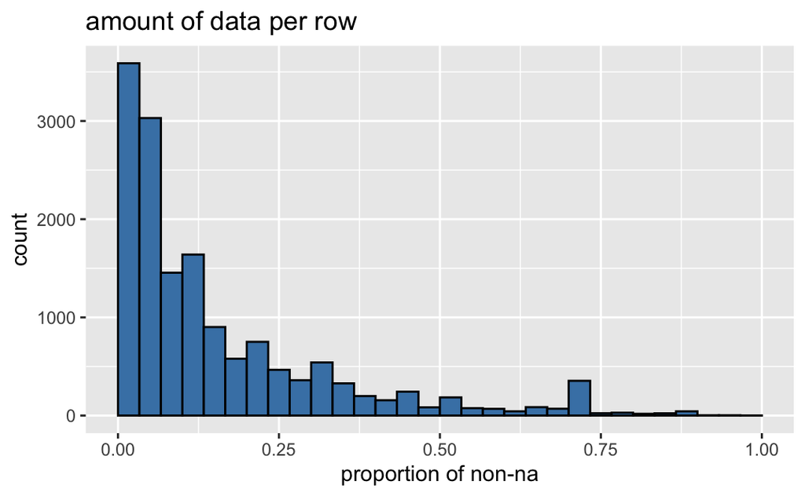

```r
LPI_data %>%
  pivot_longer(cols = `1950`:`2018`,
               names_to = 'year',
               values_to = 'count') %>%
  group_by(ID) %>%
  summarize(proportion = mean(!is.na(count))) %>%
  ggplot(aes(x = proportion)) +
    geom_histogram(breaks = seq(0,1,1/30),
                   color = 'black',
                   fill = 'steelblue') +
    labs(title = 'amount of data per row',
         x = 'proportion of non-na')
```

A very large majority of the rows have count data for less than 25% of the years. It may be worth focusing in on only rows with greater than a certain amount of count data.

Note that units are different for counts of each species.

```r
LPI_data$Units %>%
  unique() %>%
  length()
```

```
[1] 1929
```

```r
LPI_data$Units %>%
  str_to_lower() %>%
  unique() %>%
  length()
```

```
[1] 1842
```

There are 1929 different units for counts; some of which are repeats. Some of the units are different just on the basis of capitalization.

To try to get some standardization, a new dataframe, `cleaned` is made. Note that the features have also been converted to lowercase for ease of typing.

```r
# copy for cleaning
cleaned <- LPI_data

# lowercase features for convenience
names(cleaned) <- tolower(names(cleaned))

# lowercase for units
cleaned$units <- str_to_lower(cleaned$units)

# list of unique units and count
unique_units <- cleaned %>%
  group_by(units) %>%
  count()

# filter to look for counts of individuals
unique_units %>%
  filter(str_detect(units, "ind"))
```

| units | n |
| --- | --- |
| % of scent stations visited each year. does not indicate actual numbers but can be used as index of trend. | 36 |
| 10^(-2) ind / m2 | 1 |
| 10¯² individuals m¯² | 2 |
| absolute number of individuals | 1 |
| abundance (ind/km) | 6 |
| abundance (individuals) | 1 |
| abundance (no. of individuals) | 1 |
| abundance (no. of individuals/km) | 1 |
| abundance (number of individuals) | 1 |
| abundance estimate (number of individuals) | 8 |

[output cut: 509 more lines]

```r
NA
```

Many of the units are just number of individuals said in different ways. This needs to be cleaned up.

# Initial LP Data Analysis

Katie

Notebook for initial look at the Living Planet data, saved as `LPR2020.csv` in `data`. The working directory should be `final-project-bald_eagle/code`.

```r
# check working directory
getwd()
```

```
[1] "/Users/katie/Documents/MA615-b/final-project-bald_eagle/code"
```

```
/Users/katie/Documents/MA615-b/final-project-bald_eagle/code
```

```r
# packages
suppressPackageStartupMessages(library(tidyverse))
```

Importing data from CSV. ID is imported as integer; latitude, longitude, and all of the count data as double; everything else as character. Note that some of the features should be factors, but that will be taken care of later, to keep control of factor levels.

```r
LPI_data <- read_csv('../dataset/LPR2020.csv',
                     col_types =
                       cols_only(ID = col_integer(),
                                 Binomial = col_character(),
                                 Class = col_character(),
                                 Order = col_character(),
                                 Family = col_character(),
                                 Genus = col_character(),
                                 Species = col_character(),
                                 Subspecies = col_character(),
                                 Common_name = col_character(),
                                 Location = col_character(),
                                 Country = col_character(),
                                 All_countries = col_character(),
                                 Region = col_character(),
                                 Latitude = col_double(),
                                 Longitude = col_double(),
                                 Specific_location = col_character(),
                                 temperate_or_tropical = col_character(),
                                 System = col_character(),
                                 T_realm = col_character(),
                                 T_biome = col_character(),
                                 FW_realm = col_character(),
                                 FW_biome = col_character(),
                                 M_realm = col_character(),
                                 M_ocean = col_character(),
                                 M_biome = col_character(),
                                 Units = col_character(),
                                 Method = col_character(),
                                 `1950` = col_double(),
                                 `1951` = col_double(),
                                 `1952` = col_double(),
                                 `1953` = col_double(),
                                 `1954` = col_double(),
                                 `1955` = col_double(),
                                 `1956` = col_double(),
                                 `1957` = col_double(),
                                 `1958` = col_double(),
                                 `1959` = col_double(),
                                 `1960` = col_double(),
                                 `1961` = col_double(),
                                 `1962` = col_double(),
                                 `1963` = col_double(),
                                 `1964` = col_double(),
                                 `1965` = col_double(),
                                 `1966` = col_double(),
                                 `1967` = col_double(),
                                 `1968` = col_double(),
                                 `1969` = col_double(),
                                 `1970` = col_double(),
                                 `1971` = col_double(),
                                 `1972` = col_double(),
                                 `1973` = col_double(),
                                 `1974` = col_double(),
                                 `1975` = col_double(),
                                 `1976` = col_double(),
                                 `1977` = col_double(),
                                 `1978` = col_double(),
                                 `1979` = col_double(),
                                 `1980` = col_double(),
                                 `1981` = col_double(),
                                 `1982` = col_double(),
                                 `1983` = col_double(),
                                 `1984` = col_double(),
                                 `1985` = col_double(),
                                 `1986` = col_double(),
                                 `1987` = col_double(),
                                 `1988` = col_double(),
                                 `1989` = col_double(),
                                 `1990` = col_double(),
                                 `1991` = col_double(),
                                 `1992` = col_double(),
                                 `1993` = col_double(),
                                 `1994` = col_double(),
                                 `1995` = col_double(),
                                 `1996` = col_double(),
                                 `1997` = col_double(),
                                 `1998` = col_double(),
                                 `1999` = col_double(),
                                 `2000` = col_double(),
                                 `2001` = col_double(),
                                 `2002` = col_double(),
                                 `2003` = col_double(),
                                 `2004` = col_double(),
                                 `2005` = col_double(),
                                 `2006` = col_double(),
                                 `2007` = col_double(),
                                 `2008` = col_double(),
                                 `2009` = col_double(),
                                 `2010` = col_double(),
                                 `2011` = col_double(),
                                 `2012` = col_double(),
                                 `2013` = col_double(),
                                 `2014` = col_double(),
                                 `2015` = col_double(),
                                 `2016` = col_double(),
                                 `2017` = col_double(),
                                 `2018` = col_double()),
                     na = 'NULL')
```

Looking for any rows with no count data.

```r
LPI_data %>%
  select(`1950`:`2018`) %>%
  filter_all(all_vars(is.na(.)))
```

| 1950 | 1951 | 1952 | 1953 | 1954 | 1955 | 1956 | 1957 | 1958 | 1959 | 1960 | 1961 | 1962 | 1963 | 1964 | 1965 | 1966 | 1967 | 1968 | 1969 | 1970 | 1971 | 1972 | 1973 | 1974 | 1975 | 1976 | 1977 | 1978 | 1979 | … |
| --- | --- | --- | --- | --- | --- | --- | --- | --- | --- | --- | --- | --- | --- | --- | --- | --- | --- | --- | --- | --- | --- | --- | --- | --- | --- | --- | --- | --- | --- | --- |

```r
LPI_data %>%
  select(`1950`:`2018`) %>%
  filter_all(all_vars(!is.na(.)))
```

| 1950 | 1951 | 1952 | 1953 | 1954 | 1955 | 1956 | 1957 | 1958 | 1959 | 1960 | 1961 | 1962 | 1963 | 1964 | 1965 | 1966 | 1967 | 1968 | 1969 | 1970 | 1971 | 1972 | 1973 | 1974 | 1975 | 1976 | 1977 | 1978 | 1979 | … |
| --- | --- | --- | --- | --- | --- | --- | --- | --- | --- | --- | --- | --- | --- | --- | --- | --- | --- | --- | --- | --- | --- | --- | --- | --- | --- | --- | --- | --- | --- | --- |

Note that no rows have no count data, and no rows have count data for all years.

Next, finding the proportions of existent count data for each row.

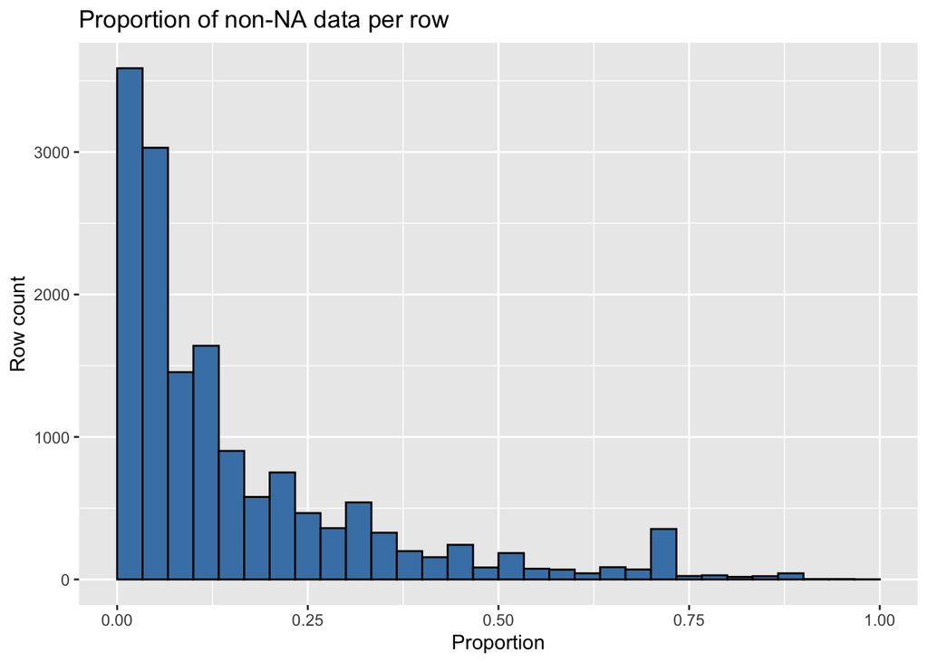

```r
LPI_data %>%
  pivot_longer(cols = `1950`:`2018`,
               names_to = 'year',
               values_to = 'count') %>%
  group_by(ID) %>%
  summarize(proportion = mean(!is.na(count))) %>%
  ggplot(aes(x = proportion)) +
    geom_histogram(breaks = seq(0,1,1/30),
                   color = 'black',
                   fill = 'steelblue') +
    labs(title = 'Proportion of non-NA data per row',
         x = 'Proportion',
         y = 'Row count')
```

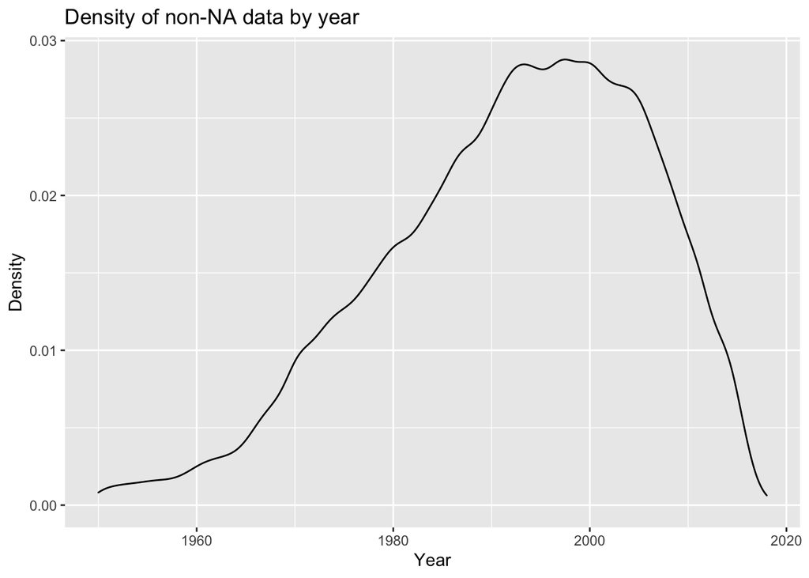

```r
LPI_data %>%
  pivot_longer(cols = `1950`:`2018`,
               names_to = 'year',
               values_to = 'count') %>%
  filter(!is.na(count)) %>%
  ggplot(aes(as.numeric(year))) +
    geom_density() +
    labs(title = 'Density of non-NA data by year',
         x = 'Year',
         y = 'Density')
```

A very large majority of the rows have count data for less than 25% of the years. It may be worth focusing in on only rows with greater than a certain amount of count data.

Note that units are different for counts of each species.

```r
LPI_data$Units %>%
  unique() %>%
  length()
```

```
[1] 1929
```

```r
LPI_data$Units %>%
  str_to_lower() %>%
  unique() %>%
  length()
```

```
[1] 1842
```

There are 1929 different units for counts; some of which are repeats. Some of the units are different just on the basis of capitalization.

To try to get some standardization, a new dataframe, `cleaned` is made. Note that the features have also been converted to lowercase for ease of typing.

```r
# copy for cleaning
cleaned <- LPI_data

# lowercase features for convenience
names(cleaned) <- tolower(names(cleaned))

# lowercase for units
cleaned$units <- str_to_lower(cleaned$units)

# list of unique units and count
unique_units <- cleaned %>%
  group_by(units) %>%
  count()

# filter to look for counts of individuals
unique_units %>%
  filter(str_detect(units, "ind"))
```

| units | n |
| --- | --- |
| % of scent stations visited each year. does not indicate actual numbers but can be used as index of trend. | 36 |
| 10^(-2) ind / m2 | 1 |
| 10¯² individuals m¯² | 2 |
| absolute number of individuals | 1 |
| abundance (ind/km) | 6 |
| abundance (individuals) | 1 |
| abundance (no. of individuals) | 1 |
| abundance (no. of individuals/km) | 1 |
| abundance (number of individuals) | 1 |
| abundance estimate (number of individuals) | 8 |

[output cut: 509 more lines]

Many of the units are just number of individuals said in different ways. This needs to be cleaned up. We can use the `forcats` package.

Since that will be time-intensive to clean, a bit more analysis can be done on the rows with larger amounts of data to reduce the number of rows to work with.